# Neuroveda

*Zpětná vazba, júlový turnus Discover*

## Hodnocení kurzu

Průměrná známka:

| Blok setkání | Průměrná známka |
| --- | --- |
| A | 1.12 |
| B | 1.05 |
| oba | 1.08 |

### Hodnocení po dnech

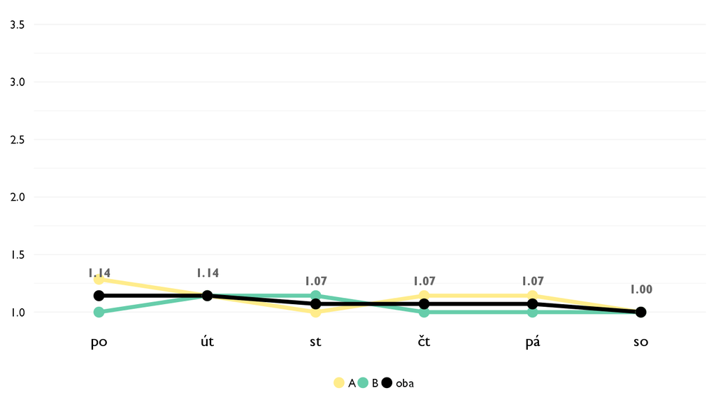

### Co se na kurzu líbilo

- Styl vyucovania, lektor miestami kladol sugestivne otazky aby sme dokazali prist na opovede hoci aj sami, ucivo bolo putave a prezentacia naozaj pomohla.
- Spôsob vysvetlovania nášho velmi mudreho lektora Mata. Je to pre mna velky vzor a navod, podla ktoreho by som sa chcela riadiť i ja. Naučil ma rozmýšlať a hladať pričiny roznych problemov novým, efektivnejšim sposobom.
- Vedecky pristup aplikacia deduktivneho myslenia a cool pokusy a vo vseobecnosti informacie
- Lektor mato bol fakt super a vie vsetko velmi dobre vysvetli a tie experimety. Boli naj
- prichadzanie na veci vlastnym rozmyslanim, teoreticke poznatky spate s praktickymi
- Názorné experimenty.
- Kurz bol neskutočne interaktívny, nikto nezostal nezapojený a boli to veci nesmierne zaujímavé.
- Rychlé tempo a hodně otázek od Maťa, bavilo mě zkoušet přijít na to, jak věci fungují, mimo pouhé přijímání informací. A experimenty!
- Páčilo sa mi, že sme mohli vidieť rôzne experimenty a kurz nebol len nudnou teóriou ale vedou v praxi. Téma bola zaujímavá a určite ma to pohlo vpred v pohľade na neurovedu. Veľmi sa mi páčilo zapálenie lektora pre kurz, ktoré bolo také nákazlivé, až sme si to užívali všetci.
- Celá vyuka a experimenty, ktoré sme skúšali boli dosť super a vtipne. Páčilo sa mi takisto ako Matej zaujímavo rozprával o všetkých témach.
- To, že som sa dozvedela mnoho vecí, kt. Sa inde len tak nedozviem..A hlavne pokusy
- pokusy a interaktivne cvicenia. intenzivna diskusia medzi ucastnikmi a lektorom. like!
- odbornost lektora a spousta pokusu
- Putave vysvetlovanie lektora, odbornost lektora a rozne experimenty.

### Co na kurzu změnit

- Ucebnu, v spolocenskej bola rano celkom zima.
- Myslím, že ak bude taky zaujimavy kazdý rok, tak si pozornost určite prietiahne, takže na nom podla mna netreba menit nic.
- Nic je to legendary
- prosim niv nemente a musite prinut mata aby z neurovedy neodisiel
- nic
- ..
- nič na ňom nemeniť, hlavne nie lektora :)
- Nic bych neměnila
- Viac citrónov. Došli až moc skoro.
- Nič
- nic. presvedcte mata macaka, nech pride aj na buduci rok :)
- uvitaaala bych mozna vic materialu predem
- …

## Hodnocení lektora

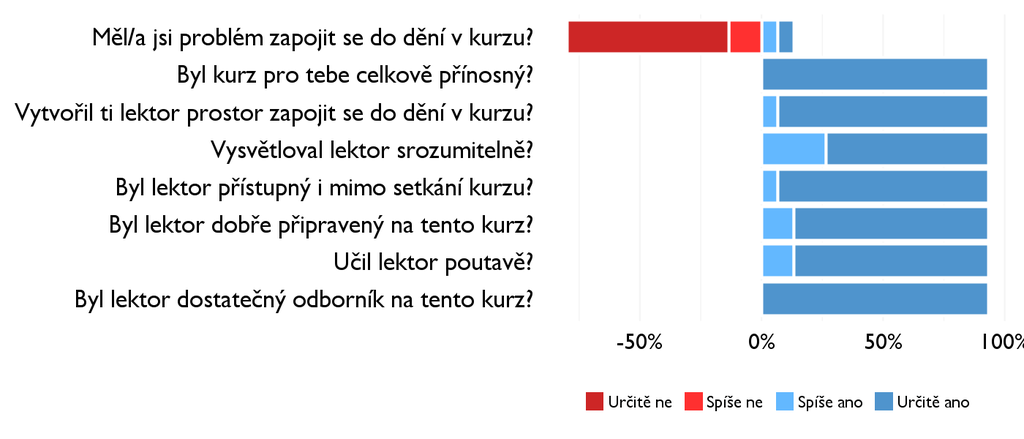

### Komentáře k lektorovi

- Ma skvely putavy sposob vyucovania
- nemam
- nemam
- Maťo, neposúvaj ho ďalej, si najlepší :)
- Občas bylo něco vysvětleno moc rychle, ale vždycky jsme se k tomu vrátili a nebyl problém :)
- Lektor bol super. Vedel odpovedať na všetky otázky a bol veľmi ústretový aj keď sme ho žiadali o knihy a nejaké užitočné rady. Spôsob učenia bol dobrý, vždy nám vysvetlil všetko, čo sme nechápali aj v prípade, že kurz skončil.
- Matej Macak rocks! :)

## Náročnost kurzu

### **Jak hodnotíš náročnost…**

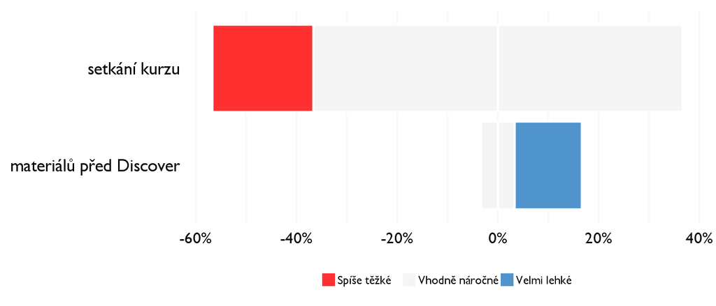

## Didaktika

### Jak lektor učí a měl by to změnit?

[figure not shown]

### Jak se studentům nejlépe učí?

[figure not shown]

## Ovlivnil tě kurz nějak?

**Pokud ano, jak? Pokud ne, proč ne?**

- V chapani principov fungovania mozgu, jeho ,,bugoch,, a v mojich zaujmoch, kedze ucivo bolo putave
- Ano, pomohol mi utvrdit sa vo svojom rozhnodnuti, čo dalej študovať a čomu sa v živote venovať.
- Ano v chuti studovat prirodne vedy
- Rozsiril mi poznaty o neurovede a tom ako mozog a neurony funguju
- motivacia venovat sa tejto oblasti viac
- ..
- minimálne budem môcť rôznymi experimentami ohurovať okolie :)
- Excitoval moje nadšení a zvědavost, těším se, až si najdu online přednášky a knížky a dozvím se víc.
- Zaujal ma a určite sa budem venovať neurovede aj v budúcnosti.
- Prinútil ma premýšľať o štúdiu neurovedy v medicíne, nad čím som predtým až tak neuvažovala.
- Áno, viac sa plánujem tomu venovať
- naucila som sa vela noveho, hlavne o fungovani ludskeho mozgu a o tom, ako casto sme klamani vlastnymi zmyslami.
- ano, mám vetsi zajem o mozek a mozna se mu chci venovat v budoucnu
- Este viac sa prehlbil moj zaujem o tuto oblast.